# Cox PH Regression: Predicting Survival Probabilities

Lecture 8A

PUBHBIO 6250

## Predicting Survival Probability

- In addition to estimating predictor effects, researchers may be interested in **predicting the survival probability** for a given patient, i.e., $S(t|\boldsymbol{x})$.
- It requires the **estimation of the baseline cumulative hazard function $H_0(t)$**.
- $H_0(t)$ is the accumulation of baseline hazard over time, formally defined as:

$$H_0(t)=\int_0^t h_0(u)du$$

## Predicting Survival Probability (Cont’d)

- $H_0(t)$ can be estimated by the **Breslow estimator** from a Cox PH model.
- Suppose we have ordered the $m$ distinct observed event times $t_1, t_2, t_3,..., t_m$.
- Let $R(t_i) =$ risk set at event time $t_i$.
- The **Breslow estimator** of the baseline cumulative hazard function is:

$$\hat{H}_0(t) = \sum_{t_i \leq t}\frac{1}{\sum_{k \in R(t_i)}\exp\big\{ \hat{\beta}_1 x_{1k} + \hat{\beta}_2 x_{2k} + \dots + \hat{\beta}_p x _{pk}\big\}},$$

where $\hat{\beta}_1, \hat{\beta}_2, \dots, \hat{\beta}_p$ are the estimated regression coefficients from a Cox PH model with $p$ predictors.

## Predicting Survival Probability (Cont’d)

- Given the estimated $\hat{H}_0(t)$, we can estimate the cumulative hazard function **for a given subject with covariate $\boldsymbol{x}$** under a Cox PH model:

$$\hat{H}(t|\boldsymbol{x})=\hat{H}_0(t)\exp\left(\hat{\beta}_1 x_1 + \dots + \hat{\beta}_p x_p\right),$$

where $\boldsymbol{x} = (x_1, \dots, x_p)$

- The **survival function** of the subject can be estimated by:

$$\hat{S}(t|\boldsymbol{x})=\exp\big\{-\hat{H}(t|\boldsymbol{x})\big\}$$

- With this estimate, $\hat{S}(t|\boldsymbol{x})$, we can:
  - Predict the survival probability of a given subject (with covariate $\boldsymbol{x}$) at time $t$.
  - Plot $\hat{S}(t|\boldsymbol{x})$ over the entire study duration for several subjects.

## Example: Predicting Survival Probability

- Using the DPCA data, fit a Cox model with predictors DPCA and bilirubin.
- Estimated survival functions at the 25th, 50th, and 75th percentiles of bilirubin (`bilirub` $= 0.8, 1.35, 3.45$) among people given control (`rx` $= 0$).

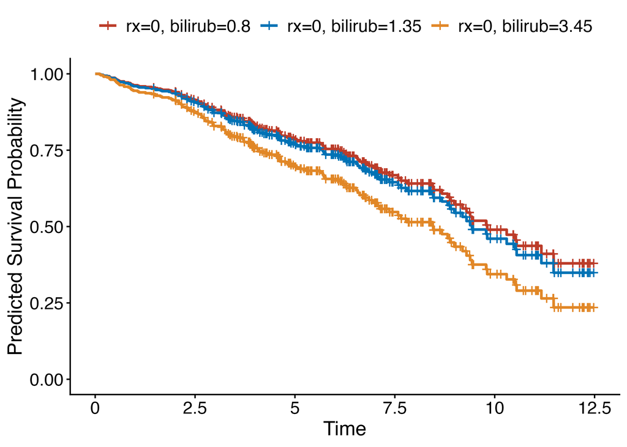

- $\hat{S}(t|\texttt{rx}, \texttt{bilirub})$ is a step function.

  *Estimated survival probability only changes at the observed event times and remains constant between two event times.*
- People with a higher level of bilirubin have lower survival probabilities.